# Matplots

In the following, Red indicates a stronger positive reaction to Photo, Cyan a stronger positive reaction to Weave, Purple an equal reaction.

When age groups are compared, younger is on the left, older is on the right

When comparing age groups, the line thicknesses are pro-rated to what they would be if sample sizes were the same in both groups. This makes the difference in response a lot easier to see.

## Matplots

The matplots are looking good, and have the option of tweaking aspect ratio of the image or thickness of lines as desired.

### Pittsburgh, full data set

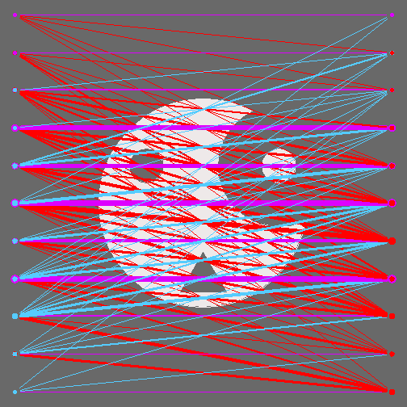

### Pittsburgh, under 50 (left) vs over 50 (right)

The difference here is that the right side has almost no blue, the thicnkess of the blue lines are very narrow.

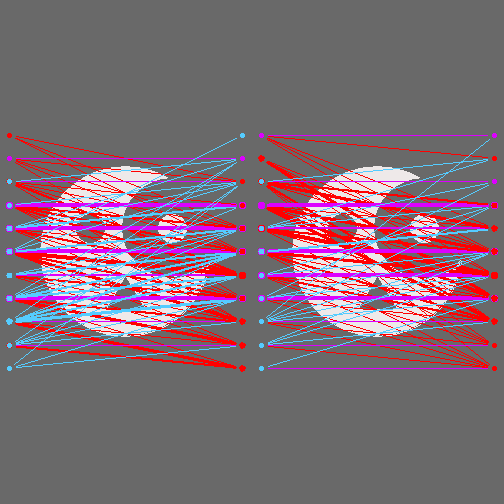

### Houston, full data set

[figure not shown]

### Houston, under 30 (left) vs over 30 (right)

Houston's under 30 subjects had a much more uniform response than the other categories, which show in the very thick lines.

Again the older population is defined more by lack of much blue than thick red lines - their exact response varied quite a bit.

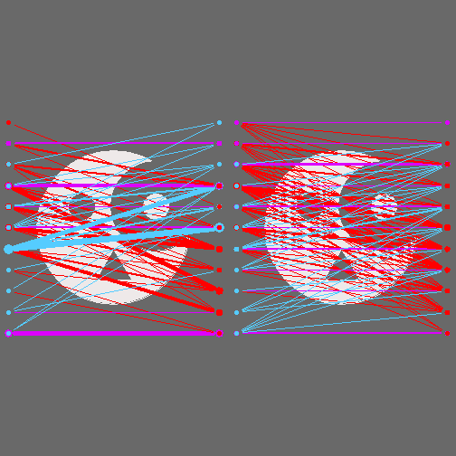

## Spot Graphs

The spot sizes were prorated in the age group data sets to appear the same relative size as if both populations were the same.

I think there probably is a better shape than “circle” for this “hollow” versions of the various shapes are also possible but I think if you go down that road the + or x or * shapes are probably better and likely easier to weave. I have a memory that diagonals are hard, so the square or “+” shapes might be of interest.

I believe the color coded tickmarks are superior than trying to put a grid on as well, but as you had positive feedback from an artistic standpoint on a gridline, I've included my favorite take on a gridline, using the same color as the lighter portion of the photographic image, allowing the gridline to blend into the image instead of dominating it.

Starts with just the spots like the original graphs, allowing focus on the data differences and see how that ties in with what the matplots show. All of the graphical options are then listed with a single plot, so they're easier to compare.

### Pittsburgh, full data set

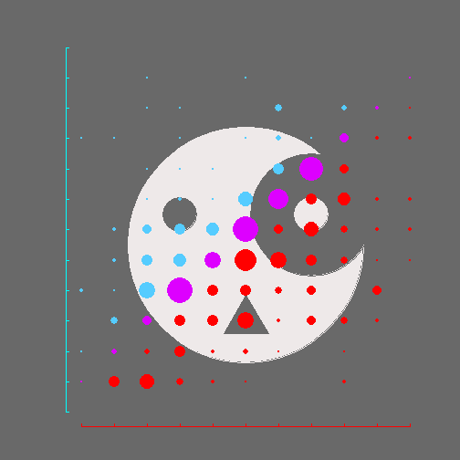

### Pittsburgh, under 50 (left) vs over 50 (right)

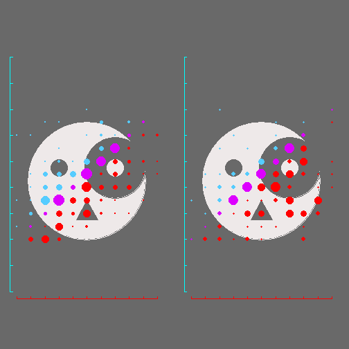

### Houston, full data set

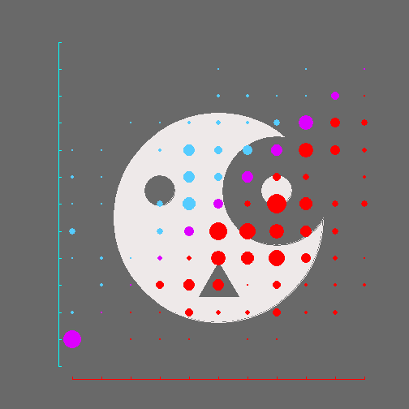

### Houston, under 30 (left) vs over 30 (right)

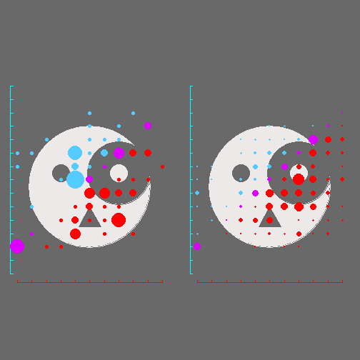

## Graphic options

Uses the Pittsburgh Spots full population as the example.

Thicknesses of lines on the +, x, * or other similar line-shapes can be adjusted in my graphics program, I just went with the defaults to illustrate the idea. The sizing that was ok for spots might not be right for a line-drawing (it might need to be bigger to show up well if it isn't a solid shape).

### Gridlines

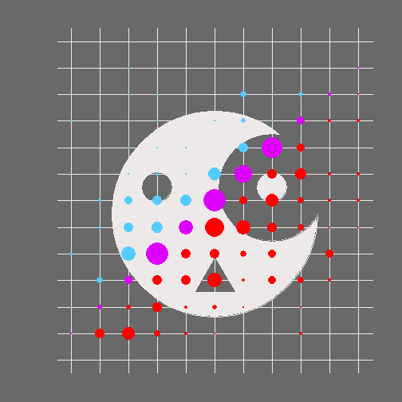

### Shapes

Some of the line shapes are interesting although they might be hard to weave.

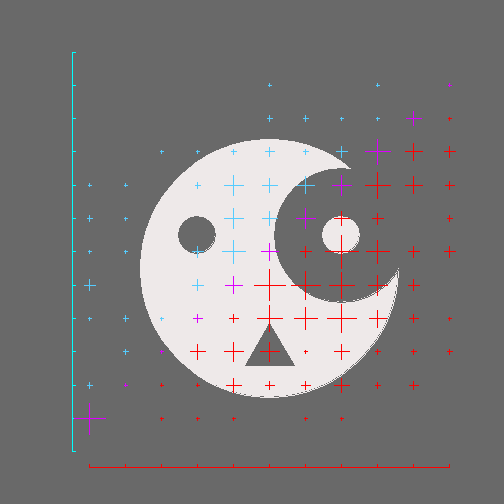

[figure not shown]

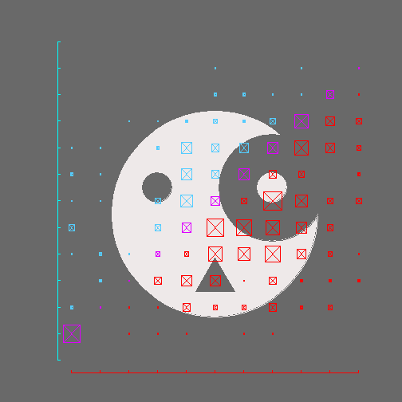

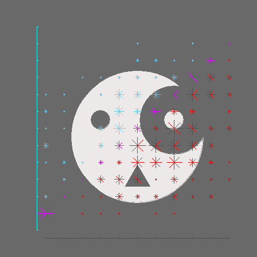

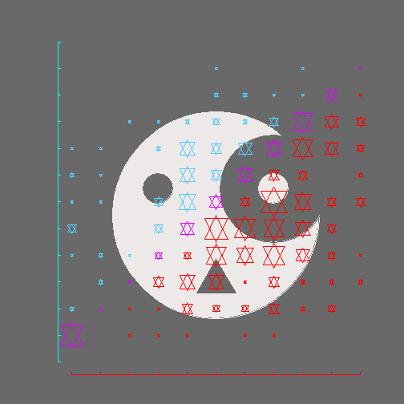

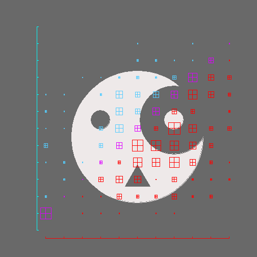

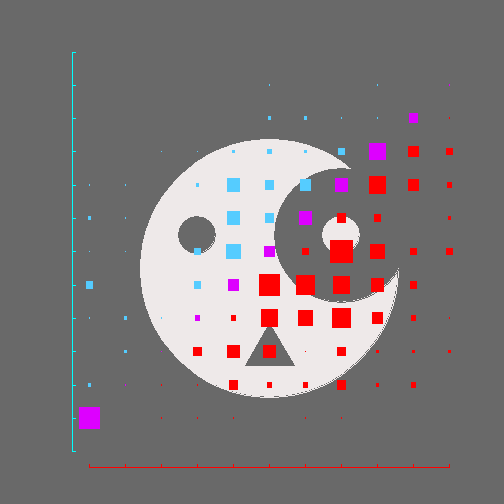

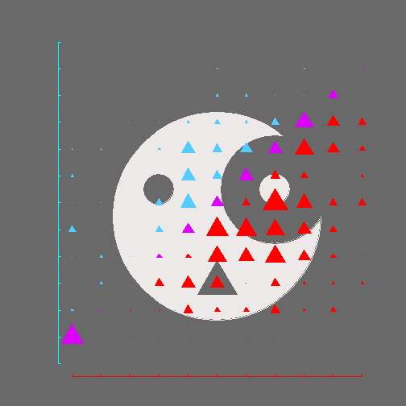

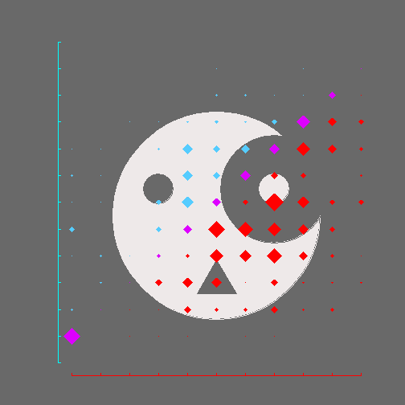

There were some interesting differences in the word choices, but delving deeper into the text I found a number where more than one emotion was present (eg, Anger and Loneliness) so these words are clearly just the more dominant of the two.

The lc_clean program performed scrubbing of similar words or synonyms to make the groupings easier to see (so Sad and Sadness were both mapped to Sad)

## Word Pairings

These are a few simple tables showing the largest shifts in reaction by individual subjects. A positive number indicates the Weave has a more positive response, a negative number indicates the Photo has a more positive response.

The idea of these charts is to see what changed emotionally during the largest shifts.

### Pittsburgh Photo More Positive

```
##          Photo         Weave Change
## 238      happy           sad     -8
## 335    curious         empty     -8
## 171  expansion     disturbed     -7
## 198 mesmerized          fear     -7
## 353        sad          soft     -7
## 48   concerned          fear     -6
## 121       calm        blurry     -6
## 129    engaged uncomfortable     -6
## 147       calm           odd     -6
## 278    inquiry         alarm     -6
## 293        sad         aware     -6
## 296 empathetic   questioning     -6
## 318 mysterious       neutral     -6
## 356        sad       curious     -6
## 368  skeptical     resentful     -6
## 90  compassion       seeking     -5
## 111 protective       nervous     -5
## 125    exposed         guilt     -5
## 133    curious     apathetic     -5
## 144      angry         wrong     -5
```

### Pittsburgh Weave More Positive

```
##          Photo        Weave Change
## 120   troubled   reflective      8
## 265    worried   interested      8
## 134     desire         fear      7
## 338       fear     peaceful      7
## 91         sad         evil      6
## 54        lost    wondering      5
## 183     butter invigorating      5
## 282        sad    beautiful      5
## 280    wishing        angry      4
## 354     lonely          sad      4
## 387  uncertain         hope      4
## 396 reflective        angry      4
## 2       caring     confused      3
## 42         sad        angry      3
## 75        fear      curious      3
## 80        fear                   3
## 142     uneasy         fear      3
## 165     amazed    concerned      3
## 191 mysterious          sad      3
## 225       fear         help      3
```

### Houston Photo More Positive

```
##          Photo      Weave Change
## 20   innocence       fear     -8
## 45   innocence       fear     -8
## 52        calm       dark     -8
## 138      happy foreboding     -8
## 200  innocence       dark     -8
## 8    intrigued  concerned     -7
## 237 empathetic discomfort     -7
## 313  nostalgia    forlorn     -7
## 347  relective reflective     -7
## 411   charming        sad     -7
## 413      light  depressed     -7
## 1       warmth        awe     -6
## 17    pleasant        not     -6
## 24     charmed  disturbed     -6
## 40    peaceful       loss     -6
## 61   innocence  ambiguity     -6
## 135  nostalgia        sad     -6
## 153       calm       want     -6
## 171     tender    anxious     -6
## 360       calm mysterious     -6
```

### Houston Weave More Positive

```
##           Photo       Weave Change
## 102     guarded comfortable      7
## 43    nostalgia     distant      6
## 64       wonder     worried      6
## 233        blah     content      6
## 421        lost     content      6
## 78      impulse         sad      5
## 185     mandala   greatness      5
## 216    peaceful     secrets      5
## 339   perplexed         sad      5
## 57       tender   concerned      4
## 101         sad  interested      4
## 111    peaceful         sad      4
## 159    pleasure   unsettled      4
## 165      lovely   emergence      4
## 172       happy        lost      4
## 178     longing                  4
## 258        calm         sad      4
## 269  protective affirmation      4
## 387 questioning     haunted      4
## 415       happy    extended      4
```

## Wordclouds

In the following, we stay with the Red-Blue convention, using Red for Photo Words and Blue for Weave Words.

When sample sizes are different, the smaller samples are pro-rated so size will be similar in both sets of graphs

### Pittsburgh (top) vs Houston (bottom)

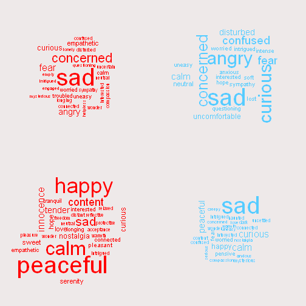

### Pittsburgh under 50 (top) vs 50+ (bottom)

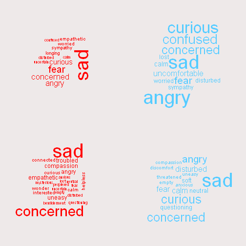

### Houston under 30 (top) vs 30+ (bottom)

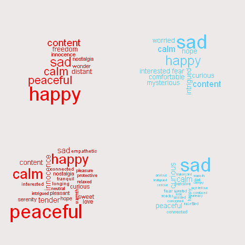

### Pittsburgh Weave more Negative (top) vs Weave More Positive (bottom)

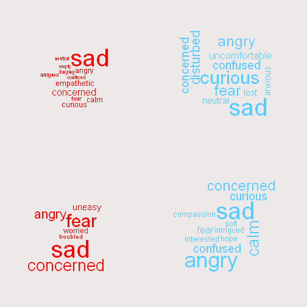

### Houston Weave more Negative (top) vs Weave More Positive (bottom)

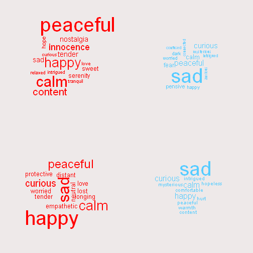